# Week 4 Homework - Global Gender Inequality Difference

Jacob Echele

26 October 2025

## Assignment

This week’s assignment is to:

- Read in global gender inequality data
- Join the global gender inequality index to spatial data of the World, creating a new column of difference in inequality between 2010 and 2019
- Share it with the World on GitHub

## Solution

First, I loaded in my packages.

```r
library(dplyr)
library(here)
library(janitor)
library(tmap)
library(tmaptools)
library(sf)
library(ggplot2)
library(countrycode)
library(tidyverse)
library(usethis)
```

Then, I read in my data and my GeoJSON.

```r
#loading in data
world_data <- read_csv("HDR25_Composite_indices_complete_time_series.csv",
                                         na="NULL",
                                         locale = locale(encoding = "latin1"))
#loading in geopackage
world_outline <- st_read("World_Countries_(Generalized)_9029012925078512962.geojson")%>%
  select(ISO)
```

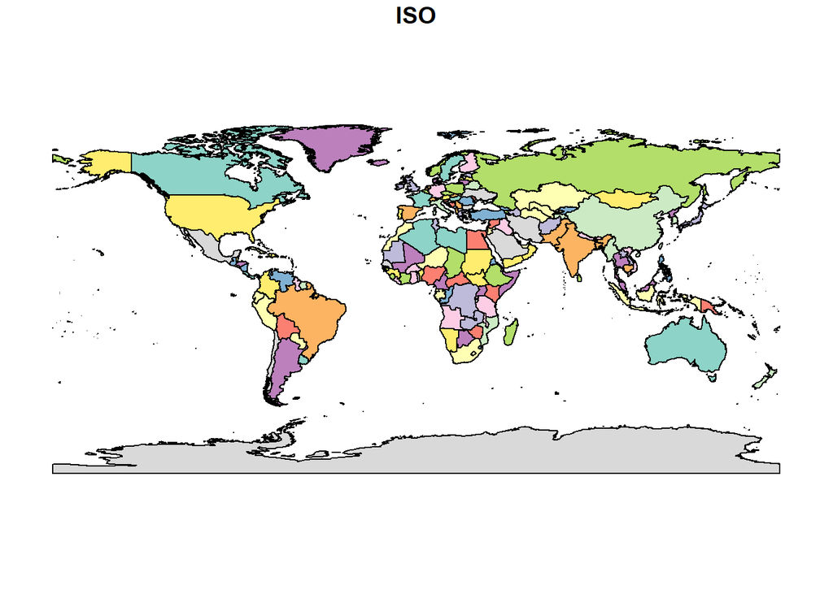

```r
plot(world_outline)
```

After reading in the numeric and spatial data, I created separate data frames for GDI in 2010 and 2019 to make it easier to join them and create a new data frame showing the difference.

```r
#creating df for 2010 data
world_data_2010 <- world_data%>%
  dplyr::select(
    contains("iso3"),
    contains("country"),
    contains("gdi_2010"),
  )

#creating df for 2019 data
world_data_2019 <- world_data%>%
  dplyr::select(
    contains("iso3"),
    contains("country"),
    contains("gdi_2019"),
  )

#creating df for difference
world_data_df <- world_data_2010%>% #initial 2010 data
  select(c(iso3, country, gdi_2010))
world_data_df <- world_data_df%>% #adding 2019 data
  left_join(.,world_data_2019)

world_data_difference <- world_data_df%>% #creating the difference
  select(iso3, country, gdi_2019, gdi_2010)%>% #keeping columns
  mutate( #actual math
    gdi_difference = gdi_2019 - gdi_2010
  )
```

Once I joined the 2010 and 2019 data and found the difference, I cleaned the column names and prepared for merging by converting between iso2 and iso3 country codes.

```r
#creating values with iso2 country codes from iso3
iso2 <- countrycode(world_data_difference$iso3,
                                          origin = "iso3c",
                                          destination = "iso2c",
                                          warn = TRUE,
                                          nomatch = NA,
                                          custom_dict = NULL,
                                          custom_match = NULL,
                                          origin_regex = NULL
)
iso2 #Produces "Some values were not matched unambiguously: ZZA.VHHD, ZZB.HHD, ZZC.HHD, ..."
```

```
##   [1] "AF" "AL" "DZ" "AD" "AO" "AG" "AR" "AM" "AU" "AT" "AZ" "BS" "BH" "BD" "BB"
##  [16] "BY" "BE" "BZ" "BJ" "BT" "BO" "BA" "BW" "BR" "BN" "BG" "BF" "BI" "CV" "KH"
##  [31] "CM" "CA" "CF" "TD" "CL" "CN" "CO" "KM" "CG" "CD" "CR" "HR" "CU" "CY" "CZ"
##  [46] "CI" "DK" "DJ" "DM" "DO" "EC" "EG" "SV" "GQ" "ER" "EE" "SZ" "ET" "FJ" "FI"
##  [61] "FR" "GA" "GM" "GE" "DE" "GH" "GR" "GD" "GT" "GN" "GW" "GY" "HT" "HN" "HK"
##  [76] "HU" "IS" "IN" "ID" "IR" "IQ" "IE" "IL" "IT" "JM" "JP" "JO" "KZ" "KE" "KI"
##  [91] "KP" "KR" "KW" "KG" "LA" "LV" "LB" "LS" "LR" "LY" "LI" "LT" "LU" "MG" "MW"
## [106] "MY" "MV" "ML" "MT" "MH" "MR" "MU" "MX" "FM" "MD" "MC" "MN" "ME" "MA" "MZ"
## [121] "MM" "NA" "NR" "NP" "NL" "NZ" "NI" "NE" "NG" "MK" "NO" "OM" "PK" "PW" "PS"
## [136] "PA" "PG" "PY" "PE" "PH" "PL" "PT" "QA" "RO" "RU" "RW" "KN" "LC" "VC" "WS"
## [151] "SM" "ST" "SA" "SN" "RS" "SC" "SL" "SG" "SK" "SI" "SB" "SO" "ZA" "SS" "ES"
## [166] "LK" "SD" "SR" "SE" "CH" "SY" "TJ" "TZ" "TH" "TL" "TG" "TO" "TT" "TN" "TM"
## [181] "TV" "TR" "UG" "UA" "AE" "GB" "US" "UY" "UZ" "VU" "VE" "VN" "YE" "ZM" "ZW"
## [196] NA   NA   NA   NA   NA   NA   NA   NA   NA   NA   NA
```

```r
#adding iso2 values to world_data_difference
world_data_difference <- world_data_difference%>%
  add_column(iso2, .before= "iso3")
```

Then, I merged the data in order to be able to plot.

```r
#merging world_data_difference and world_outline
merged_world_difference <- world_outline%>%
  left_join(world_data_difference, by = c("ISO" = "iso2"))
```

Finally, I plotted the data.

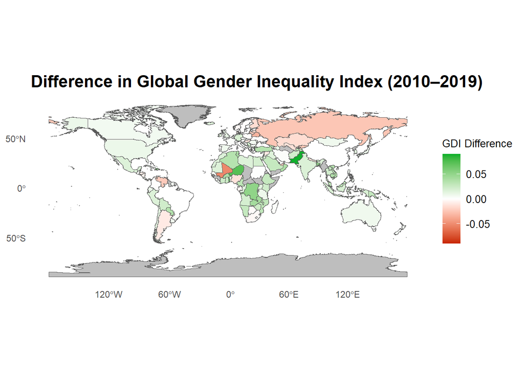

```r
#plotting merged_data_difference
GGII_merged_world_difference <- ggplot(merged_world_difference) +
  geom_sf(aes(fill = gdi_difference), alpha = 1) +
  scale_fill_gradient2(
    low = "#C72000",
    mid = "white",
    high = "#00B029",
    midpoint = 0,
    na.value = "grey",
    name = "GDI Difference",
    labels = scales::label_number(accuracy = 0.01),
    limits = c(-0.09, 0.09) #limits to provide more detail through color variation; Yemen is extreme outlier and made most of the map white
  ) +
  labs(
    title = "Difference in Global Gender Inequality Index (2010–2019)",
  ) +
  theme_minimal() +
  theme(
    legend.position = "right",
    legend.text = element_text(size = 10),
    legend.title = element_text(size = 10),
    plot.title = element_text(size = 16, face = "bold"),
    panel.grid = element_blank()
  )
plot(GGII_merged_world_difference)
```

I decided to add limits to the map to ensure that it was more readable. Yemen was a large outlier (negative value), therefore originally making the majority of the map white (values close to zero). By adding the limits, more detail became apparent and the color variation provides much more information to the viewer.

## Sources

- Global Gender Inequality Data: https://hdr.undp.org/data-center/documentation-and-downloads
- Global Spatial Data: https://hub.arcgis.com/datasets/2b93b06dc0dc4e809d3c8db5cb96ba69_0/explore?location=-0.135225%2C0.000000%2C1.41